# Logistic regression

# 1 Learning Objectives

- Know how to use the `glm()` function in R
- Carry out logistic regression in R

**Duration - 90 minutes**

# 2 Logistic Regression : R

So in the last lesson we looked at why fitting a linear model to predict a categorical variable didn’t work and we introduced to the logistic function and how we can use it to perform logistic regression. Now let’s look at fitting a logistic model in R.

If we are not in the same project then let’s load in the data again:

```r
library(tidyverse)
library(janitor)

mortgage_data <- read_csv("data/mortgage_applications.csv") %>%
  clean_names()

head(mortgage_data)
```

| tu_score | employed | age | accepted |
| --- | --- | --- | --- |
| 433 | TRUE | 28 | TRUE |
| 93 | TRUE | 52 | FALSE |
| 368 | FALSE | 63 | FALSE |
| 665 | TRUE | 42 | TRUE |
| 687 | TRUE | 38 | TRUE |
| 594 | TRUE | 27 | FALSE |

# 3 Logistic: Single continuous predictor

When we did simple linear regression, used the `lm()` function to perform a least squares fit. There, it was easy to calculate the sum of squared errors as a measure of how well the model fits the data, as we had a set of $(x_i,y_i)$ sample data and the corresponding set of $(x_i, \widehat{y}_i)$ estimates from the regression.

The situation is more complicated in the case of logistic regression, as we observe only binary outcomes directly (i.e. ‘accepted’/‘declined’ for each application) and not the log-odds that we would need to fit the model using a least squares approach.

So, we use the **generalised linear model** fitting function `glm()` to do the job for us. This uses a fitting method called **maximum likelihood estimation** (and not least squares as R used for linear regression). Don’t worry too much about this, we’ll just think of `glm()` as a ‘turbocharged’ version of `lm()`, free of some of its constraints!

Let’s use `glm()` to run logistic regression on `mortgage_data`

```r
mortgage_data_logreg_model <- glm(accepted ~ tu_score, data = mortgage_data, family = binomial(link = 'logit'))
mortgage_data_logreg_model
```

```
##
## Call:  glm(formula = accepted ~ tu_score, family = binomial(link = "logit"),
##     data = mortgage_data)
##
## Coefficients:
## (Intercept)     tu_score
##   -4.575035     0.008475
##
## Degrees of Freedom: 999 Total (i.e. Null);  998 Residual
## Null Deviance:       1170
## Residual Deviance: 792.1     AIC: 796.1
```

The argument `family = binomial(link = 'logit')` is what tells `glm()` to perform a logistic regression. The `glm()` function is very powerful, and can fit many different types of linear model, but here we’re limiting ourselves to logistic regression.

As a reminder, our logistic regression formula is:

$$\ln(\textrm{odds}_\textrm{success}(x)) = b_0 + b_1 \times x$$
where the constant ($b_0$) moves the curve left and right and the slope ($b_1$) defines the steepness of the curve.

and so with our values plugged in, we get:

$$\ln \big(\textrm{odds}_\textrm{success}(x) \big)=-4.575035 + 0.008475 \times x$$

Let’s plot the estimated probability as a function of `tu_score`

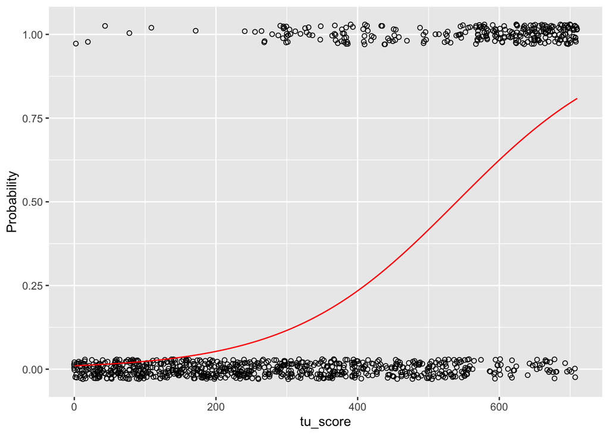

```r
library(modelr)

predict_log <- tibble(tu_score = seq(0, 710, 1)) %>%
              add_predictions(mortgage_data_logreg_model, type = 'response') # argument type = 'response' is used in glm models

ggplot(mortgage_data) +
  geom_jitter(aes(x = tu_score, y = as.integer(accepted)), shape = 1,
              position = position_jitter(h = 0.03)) +
   geom_line(data = predict_log, aes(x = tu_score , y = pred), col = 'red') +
  ylab("Probability")
```

Yay - we see the ‘S’ shaped probability curve of the logistic function! The estimated probability is now always within the bounds $0 \le \widehat{\textrm{prob}} \le 1$.

## 3.1 Prediction

We can use `add_predictions()` to predict the probability of acceptance, technically at any `tu_score`, although we should in practice limit ourselves to `tu_score`s within the range of the fitted sample data.

> **Task - 5 mins**

> Use and amend the code above to predict the probability of getting a mortgage application accepted with a `tu_score` of 594.

> **Solution**

> ```r
> tibble(tu_score = 594) %>%
>   add_predictions(mortgage_data_logreg_model, type='response')
> ```

> | tu_score | pred |
> | --- | --- |
> | 594 | 0.6127971 |

> So this tells us that the probability of acceptance is 0.61 for a score of 594.

> We can also input our values of $b_0$ and $b_1$ into the formula to calculate and double check:

> $$\widehat{\textrm{prob}}(594)=\frac{1}{1+e^{-(-4.575035 + 0.008475 \times 594)}} = 0.6128$$

## 3.2 Interpretation of $b_1$ for a continuous predictor

Now we turn to the question “How should we interpret $b_1$” in logistic regression”? We will start by considering this when $x$ is a continuous predictor (as it is in our example here with `tu_score`).

In simple linear regression $ =b_0 + b_1 * x $, the interpretation of $b_1$ was straightforward: if the independent variable $x$ increases by one unit, then the estimate of the dependent variable $\widehat{\textrm{y}}$ changes by $b_1$ units, increasing or decreasing as $b_1$ is positive or negative, respectively.

Let’s look at our logistic function again:

$$\ln \big(\textrm{odds}_\textrm{success}(x) \big)=b_0 + b_1 * x$$
So if the independent variable $x$ increases by one unit, then the estimate of the log odds of success changes by $b_1$ units, increasing or decreasing as $b_1$ is positive or negative, respectively. Hmm, that’s not very easy to understand what that means!

We want to do a bit of mathematical manipulation to rearrange our equation so we can explain this a different way. We provide the end result, but click below if you’d like to see the details.

**Interpretation of $b_1$ - mathematical details**

Let’s remind ourselves of the linear model we are fitting

$$\ln(\textrm{odds}_\textrm{success}(x)) = b_0+b_1 \times x \; \; \; \; \; \textrm{[I]}$$

Now let’s think what happens if we change the value of the independent variable

$$\ln(\textrm{odds}_\textrm{success}(x + \textrm{change})) = b_0+b_1 \times (x + \textrm{change}) = b_0+b_1 \times x + b_1 \times \textrm{change} \; \; \; \; \; \textrm{[II]}$$

Next, subtract equation $\textrm{[I]}$ from equation $\textrm{[II]}$. Then terms $b_0$ and $b_1 \times x$ cancel, and we are left with

$$\ln(\textrm{odds}_\textrm{success}(x + \textrm{change})) - \ln(\textrm{odds}_\textrm{success}(x)) = b_1 \times \textrm{change}$$

We now use the ‘log of a division’ rule in reverse

$$\ln \Big( \frac{\textrm{odds}_\textrm{success}(x + \textrm{change})}{\textrm{odds}_\textrm{success}(x)} \Big) = b_1 \times \textrm{change}$$

How do we get rid of the $\ln()$ on the left hand side? Think about how to ‘undo’ a logarithm. We exponentiate both sides, then ‘$e$ to the power of…’ cancels $\ln()$ on the left hand side!

We end up with

$$\frac{\textrm{odds}_\textrm{success}(x + \textrm{change})}{\textrm{odds}_\textrm{success}(x)} = e^{b_1 \times \textrm{change}}$$

We call the left hand side of this equation the **odds ratio**.

It might help to think of this as

$$\textrm{odds of success after change in }x = e^{b_1 \times \textrm{change in }x} \times \textrm{odds of success before change in } x$$

How do we apply this in practice? Let’s get the odds of having an accepted application at a particular `tu_score`, say at a value $594$.

```r
odds_at_594 <- tibble(tu_score = 594) %>%
  add_predictions(mortgage_data_logreg_model, type='response') %>%
  mutate(odds = pred/(1-pred)) %>%
  select(odds)

odds_at_594
```

| odds |
| --- |
| 1.582625 |

How do these odds change if we **increase** `tu_score` by, say, $50$ points to $644$? The maths above tells us the odds will change by a factor $e^{b_1 \times \textrm{change in }x} = e^{b_1 \times 50}$. So we need to get coefficient $b_\textrm{tu_score}$ from `mortgage_data_logreg_model` and then use it to work out the factor multiplying the odds.

The `broom` library takes the messy output of built-in functions in R, such as `lm()` and `glm()`, and converts them to tidy data frames. The `tidy()` function from this package will pull out the information we’re interested from a `glm` object in tidy format:

```r
library(broom)

b_tu_score <- tidy(mortgage_data_logreg_model) %>%
  filter(term == "tu_score") %>%
  select(estimate)

b_tu_score
```

| estimate |
| --- |
| 0.00847495 |

```r
odds_factor <- exp(b_tu_score * 50)

# let's see the odds factor
odds_factor
```

| estimate |
| --- |
| 1.527676 |

```r
# now calculate the new odds
odds_at_644 <- odds_factor * odds_at_594
odds_at_644
```

| estimate |
| --- |
| 2.417739 |

Let’s check if this is correct by getting the probability of acceptance at $644$ and calculating the odds directly.

```r
tibble(tu_score = 644) %>%
  add_predictions(mortgage_data_logreg_model, type='response') %>%
  mutate(odds = pred/(1-pred)) %>%
  select(odds)
```

| odds |
| --- |
| 2.417739 |

Phew, this matches what we got before!

> **Task - 5 mins**

> How do the odds of acceptance change if we **decrease** `tu_score` by $50$ points from $594$ to $544$? Calculate the new odds using `R`.

> [**Hint** - the $\textrm{change in }x$ here is $-50$]

> **Solution**

> ```r
> # we can reuse b_tu_score and odds_at_594
> odds_factor <- exp(b_tu_score * -50)
> # let's see the odds factor
> odds_factor
> ```

> | estimate |
> | --- |
> | 0.6545891 |

> ```r
> # and now use it
> odds_at_544 <- odds_factor * odds_at_594
> odds_at_544
> ```

> | estimate |
> | --- |
> | 1.035969 |

> The odds decrease to just over 1 in favour!

**Some things to note:**

Notice that the factor $e^{b_1 \times \textrm{change in }x }$ **doesn’t depend on $x$**. What does this mean?

- If we increase `tu_score` by $50$ points from $1$ to $51$, the odds will increase by the factor $1.527676$ we calculated above.
- Similarly, an increase in `tu_score` from $660$ to $710$ improves the odds by **exactly the same factor**.

Note however that this is a **factor**, and that $\textrm{new odds} = \textrm{factor} \times \textrm{old odds}$. So:

- the factor by which the odds changes **does not depend** upon $x$, as we’ve seen
- the absolute change in odds **depends** upon the odds from which we start, and these odds **depend** upon $x$.

So to recap the difference between interpretation of $b_1$ in linear vs. logistic regression:

- In simple linear regression with a continuous predictor, the interpretation of $b_1$ is if $x$ increases by one unit, then the estimate of the dependent variable $y$ changes by b1 units, increasing or decreasing as $b_1$ is positive or negative, respectively.
- In simple logistic regression the interpretation of $b_1$ is the independent variable $x$ increases by one unit, then the odds will change by a factor of $e^{b_1}$.

# 4 Logistic: Multiple predictors

Broadening the scope of logistic regression to include multiple predictors is similar to the process of going from simple linear regression to multiple regression: we now include the relevant predictors in the formula object.

We saw from our inital data exploration that `age` and `employed` status also looked to be of interest in terms of predicting `accepted` so let’s try adding these in as precitors in our model:

$$\ln \big(\textrm{odds}_\textrm{success}(x) \big) = b_0 + b_{\textrm{age}} * \textrm{age} + b_{\textrm{employed}} * \textrm{employed}+ b_{\textrm{tu_score}} \times \textrm{tu_score}$$

```r
mortgage_data_multi_logreg_model <- glm(accepted ~ tu_score +  employed + age, data = mortgage_data, family = binomial(link = 'logit'))

mortgage_data_multi_logreg_model
```

```
##
## Call:  glm(formula = accepted ~ tu_score + employed + age, family = binomial(link = "logit"),
##     data = mortgage_data)
##
## Coefficients:
##  (Intercept)      tu_score  employedTRUE           age
##     -4.62854       0.00673       1.48034      -0.00126
##
## Degrees of Freedom: 999 Total (i.e. Null);  996 Residual
## Null Deviance:       1170
## Residual Deviance: 740   AIC: 748
```

As with linear regression, we can get out estimates, errors, and p-values out for each of our predictors, alongside information about how good a fit the model is for our data.

But, as for multiple linear regression, we need to think carefully about the statistical significance of each predictor we add into the model. A good first step in this direction is to examine the $p$-value of each predictor.

```r
tidy_out <- clean_names(tidy(mortgage_data_multi_logreg_model))
tidy_out
```

| term | estimate | std_error | statistic | p_value |
| --- | --- | --- | --- | --- |
| (Intercept) | -4.628539329 | 0.4303343969 | -10.7556806 | 5.572114e-27 |
| tu_score | 0.006730118 | 0.0005692479 | 11.8228250 | 2.975086e-32 |
| employedTRUE | 1.480341044 | 0.2114793584 | 6.9999316 | 2.560875e-12 |
| age | -0.001260001 | 0.0070633577 | -0.1783856 | 8.584202e-01 |

Here we see that `tu_score` and `employed` are both significant at $\alpha = 0.05$, but `age` is not significant. So we end up with:

$$\ln \big(\textrm{odds}_\textrm{success}(x) \big) = b_0 + b_{\textrm{employed}} \times \textrm{employed}+ b_{\textrm{tu_score}} \times \textrm{tu_score}$$
which is fitted as:

$$\ln \big(\textrm{odds}_\textrm{success}(x) \big) = -4.628539329 + 1.480341044 \times \textrm{employed}+ 0.006730118 \times \textrm{tu_score}$$

# 5 Interpretation of $b_1$ for a categorical predictor

We know how to interpret the coefficient for a continuous predictor but what about a categorical predictor such as `employed`:

```r
b_employedTRUE <- tidy(mortgage_data_multi_logreg_model) %>%
  filter(term == "employedTRUE") %>%
  select(estimate)

b_employedTRUE
```

| estimate |
| --- |
| 1.480341 |

> **Task - 5 mins**

> Think about how to interpret this coefficient for a categorical predictor, building out logically from what you learned above about interpreting $b$ values for continuous predictors.
> - Think about the odds **relative to the reference level** of the predictor variable

> **Solution**

> In this case, the reference level of the `employed` variable is `FALSE`, so the odds ratio

> $$\frac{\textrm{odds}(\textrm{employed}=\textrm{TRUE})}{\textrm{odds}(\textrm{employed}=\textrm{FALSE})}= \textrm{odds ratio} = \textrm{exp}(b_\textrm{employedTRUE})$$

> ```r
> odds_ratio = exp(b_employedTRUE)
> odds_ratio
> ```

> | estimate |
> | --- |
> | 4.394444 |

> On average, a customer’s odds of being accepted for a mortgage are $4.39$ times higher if they are employed rather than not employed.

# 6 Recap

- What `R` function do we use to fit a logistic regression model to sample data?

  **Answer**

  We use the `glm()` function, passing in the argument `family = binomial(link = "logit")` to select logistic regression.
- What `R` function do we use to predict probabilities from a fitted logistic regression model?

  **Answer**

  As in simple linear regression, we use the `add_predictions()` function from `modelr`, passing in the argument `type = "response"`
- How do we interpret the regression coefficient $b_1$ obtained from logistic regression?

  **Answer**

  This depends on whether the coefficient relates to a continuous or categorical predictor:  
  **Continuous case**  
  It relates a change in predictor variable value $x$ to a change in odds as follows

$$\textrm{odds of success after change in }x = e^{b_1 \times \textrm{change in }x} \times \textrm{odds of success before change in } x$$

**Categorical case**

The odds of success for the *named level* relative to the *reference level* of the predictor are

$$\frac{\textrm{odds}(\textrm{named level})}{\textrm{odds}(\textrm{reference level})}= \textrm{odds ratio} = \textrm{exp}(b_\textrm{named_level})$$